# EDA about UCM

```python
import matplotlib.pyplot as plt
import pandas as pd
import numpy as np
```

## Age

```python
df_UCM_age = pd.read_csv("../data/data_UCM_age.csv")
```

```python
df_UCM_age.head()
```

|  | row | col | data |
| --- | --- | --- | --- |
| 0 | 2 | 4 | 1.0 |
| 1 | 7 | 10 | 1.0 |
| 2 | 8 | 4 | 1.0 |
| 3 | 10 | 4 | 1.0 |
| 4 | 12 | 4 | 1.0 |

```python
df_UCM_age.describe()
```

|  | row | col | data |
| --- | --- | --- | --- |
| count | 30317.000000 | 30317.000000 | 30317.0 |
| mean | 15521.581324 | 4.584293 | 1.0 |
| std | 8945.211104 | 2.164009 | 0.0 |
| min | 2.000000 | 1.000000 | 1.0 |
| 25% | 7805.000000 | 3.000000 | 1.0 |
| 50% | 15559.000000 | 4.000000 | 1.0 |
| 75% | 23293.000000 | 6.000000 | 1.0 |
| max | 30909.000000 | 10.000000 | 1.0 |

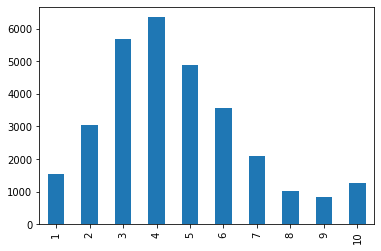

```python
df_UCM_age['col'].value_counts().sort_index().plot.bar()
```

### Advanced plots with URM

```python
df_URM = pd.read_csv("../data/data_train.csv")
```

```python
df_URM.head()
```

|  | row | col | data |
| --- | --- | --- | --- |
| 0 | 0 | 3568 | 1.0 |
| 1 | 0 | 3827 | 1.0 |
| 2 | 0 | 4844 | 1.0 |
| 3 | 0 | 5734 | 1.0 |
| 4 | 0 | 6518 | 1.0 |

Let's see if the users in URM contains all the users in UCM_age or not

```python
URM_users = df_URM.row.unique()
print("There are %d users in URM"%len(URM_users), end="")
UCM_age_users = df_UCM_age.row.unique()
print(", while there are %d users in UCM_age."%len(UCM_age_users))
mask = np.in1d(URM_users, UCM_age_users, assume_unique=True)
print("But there are %d users in URM and not in UCM_age"%len(URM_users[~mask]))
```

```
There are 27255 users in URM, while there are 30317 users in UCM_age.
But there are 517 users in URM and not in UCM_age
```

#### Most active user

Let's look into the most active users: 10% most active

```python
user_activity = df_URM['row'].value_counts()
user_activity.describe(percentiles=[0.1, 0.2, 0.3, 0.4, 0.5, 0.6, 0.7, 0.8, 0.9])
```

```
count    27255.000000
mean        14.626160
std         18.855008
min          1.000000
10%          1.000000
20%          3.000000
30%          5.000000
40%          6.000000
50%          9.000000
60%         12.000000
70%         16.000000
80%         22.000000
90%         34.000000
max        677.000000
Name: row, dtype: float64
```

```python
most_active_users = user_activity[user_activity >= user_activity.quantile(q=0.9)].index
most_active_users
```

```
Int64Index([   63, 27770, 27771, 27812, 20651,  3943, 25013, 10067,  2906,
            30910,
            ...
            10915, 16491, 13376, 19993, 16758, 26416,  7464, 17604, 29547,
            26915],
           dtype='int64', length=2835)
```

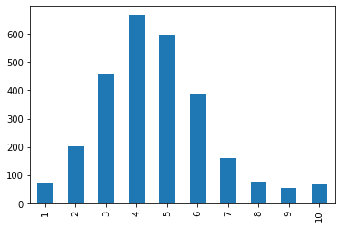

```python
df_UCM_age[df_UCM_age.row.isin(most_active_users)].col.value_counts().sort_index().plot.bar()
```

It seems that by looking at the most active users, the distribution of the age is still the same. There is no correlation between most active users and age. Let's now see the least active users

#### Least active users

Let's look into the 40% least active users

```python
least_active_users = user_activity[user_activity <= user_activity.quantile(q=0.4)].index
least_active_users
```

```
Int64Index([12308, 12701, 23267,  6635,  1672, 12110,  1434,  8011,  8164,
             9119,
            ...
             2582,  6053, 15173, 30377, 14864, 21933, 30121, 19432, 17385,
            30776],
           dtype='int64', length=11068)
```

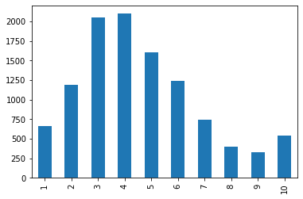

```python
df_UCM_age[df_UCM_age.row.isin(least_active_users)].col.value_counts().sort_index().plot.bar()
```

Overall, there is no big difference in the distribution of most active users and least active users between the overall distribution

#### User activity for each age

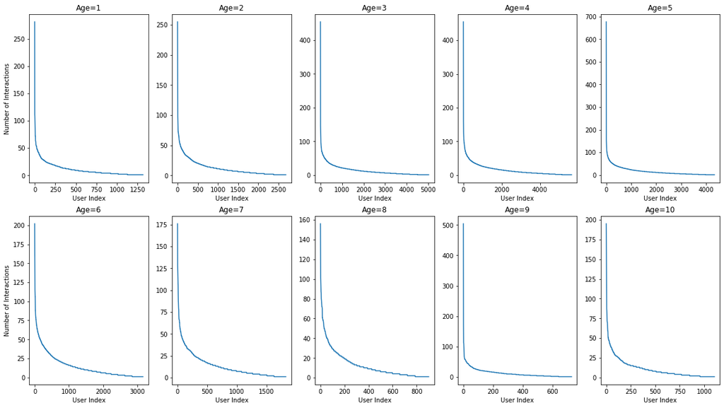

```python
ages = df_UCM_age.col.sort_values().unique()

fig, ax = plt.subplots(2, 5, figsize=(20, 11))

for i in range(len(ages)):
    users_in_age_i = df_UCM_age[df_UCM_age.col==ages[i]].row.values
    ax[i//5][i%5].plot(df_URM[df_URM.row.isin(users_in_age_i)].groupby(by='row').\
                       sum(axis=1)['data'].sort_values(ascending=False).values)
    ax[i//5][i%5].set_xlabel('User Index')
    if i%5==0:
        ax[i//5][i%5].set_ylabel('Number of Interactions')
    ax[i//5][i%5].set_title('Age=%d'%ages[i])
```

From these user activity, it is quite impossible to see any interesting and meaningful information

## Region

```python
df_UCM_region = pd.read_csv("../data/data_UCM_region.csv")
```

```python
df_UCM_region.head()
```

|  | row | col | data |
| --- | --- | --- | --- |
| 0 | 0 | 6 | 1.0 |
| 1 | 0 | 0 | 1.0 |
| 2 | 1 | 7 | 1.0 |
| 3 | 1 | 0 | 1.0 |
| 4 | 2 | 5 | 1.0 |

```python
df_UCM_region.describe()
```

|  | row | col | data |
| --- | --- | --- | --- |
| count | 26609.000000 | 26609.000000 | 26609.0 |
| mean | 15056.229885 | 5.594573 | 1.0 |
| std | 8868.603105 | 1.553131 | 0.0 |
| min | 0.000000 | 0.000000 | 1.0 |
| 25% | 7315.000000 | 5.000000 | 1.0 |
| 50% | 14936.000000 | 6.000000 | 1.0 |
| 75% | 22686.000000 | 7.000000 | 1.0 |
| max | 30910.000000 | 7.000000 | 1.0 |

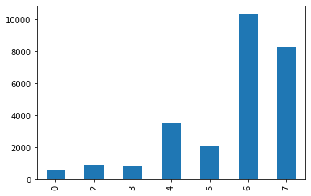

```python
df_UCM_region['col'].value_counts().sort_index().plot.bar()
```

### Advanced plots with URM

#### Most active users

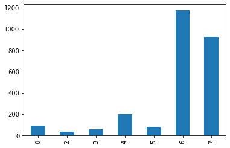

```python
df_UCM_region[df_UCM_region.row.isin(most_active_users)].col.value_counts().sort_index().plot.bar()
```

#### Least active users

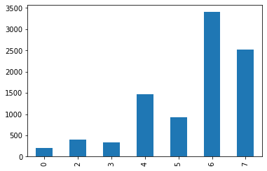

```python
df_UCM_region[df_UCM_region.row.isin(least_active_users)].col.value_counts().sort_index().plot.bar()
```

Overall, it seems there is less users in region 4 when it is active, but more users in region 4 when it is inactive

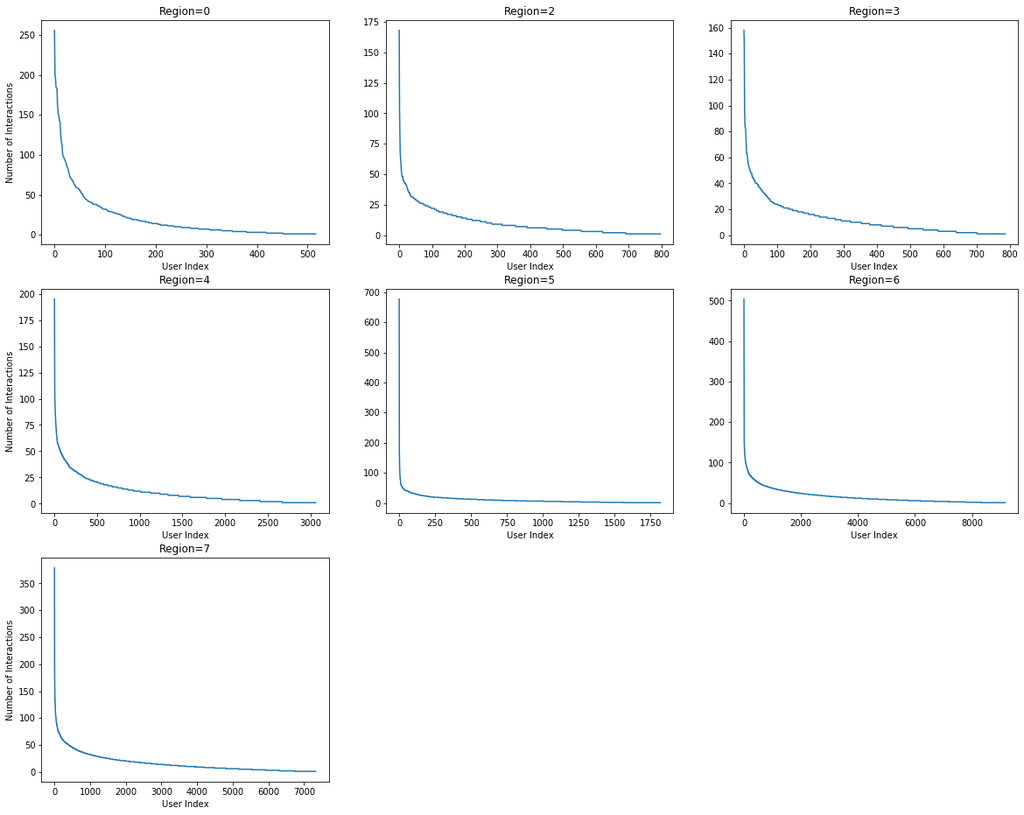

```python
regions = df_UCM_region.col.sort_values().unique()

fig, ax = plt.subplots(3, 3, figsize=(20, 16))

for i in range(len(regions)):
    users_in_region_i = df_UCM_region[df_UCM_region.col==regions[i]].row.values
    ax[i//3][i%3].plot(df_URM[df_URM.row.isin(users_in_region_i)].groupby(by='row').\
                       sum(axis=1)['data'].sort_values(ascending=False).values)
    ax[i//3][i%3].set_xlabel('User Index')
    if i%3==0:
        ax[i//3][i%3].set_ylabel('Number of Interactions')
    ax[i//3][i%3].set_title('Region=%d'%regions[i])

ax[2][1].set_visible(False)
ax[2][2].set_visible(False)
```

There are regions with a very different types of users:

- For example, in region=5, the user activity is very high for some users while a lot of users has almost 0 interactions
- Another constrant type is region=0: in this case, the user activity are distributed among lots of users and the hyperbole is not so steep

## Age-Region

```python
df_UCM_age_region = pd.merge(df_UCM_age, df_UCM_region, on='row')
```

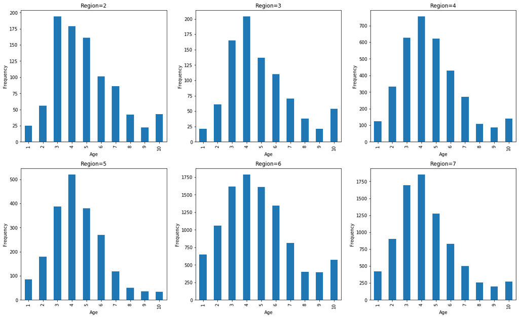

```python
regions = df_UCM_age_region['col_y'].sort_values().unique()

fig, ax = plt.subplots(2, 3, figsize=(20, 12))

for i in range(len(regions)):
    df_UCM_age_region[df_UCM_age_region.col_y == regions[i]]['col_x'].value_counts().sort_index().plot.bar(ax=ax[i//3][i%3])
    ax[i//3][i%3].set_xlabel('Age')
    ax[i//3][i%3].set_ylabel('Frequency')
    ax[i//3][i%3].set_title('Region=%d'%regions[i])
```

By changing the region, the distribution of the age is still very similar to the original ones except some small changes.

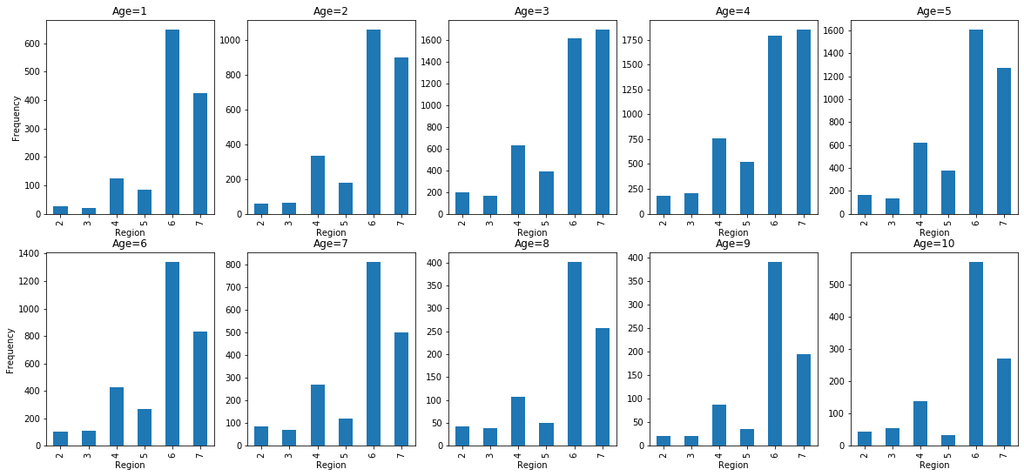

```python
ages = df_UCM_age_region['col_x'].sort_values().unique()

fig, ax = plt.subplots(2, 5, figsize=(20, 9))

for i in range(len(ages)):
    df_UCM_age_region[df_UCM_age_region.col_x == ages[i]]['col_y'].\
            value_counts().sort_index().plot.bar(ax=ax[i//5][i%5])
    ax[i//5][i%5].set_xlabel('Region')
    if i%5==0:
        ax[i//5][i%5].set_ylabel('Frequency')
    ax[i//5][i%5].set_title('Age=%d'%ages[i])
```

It is possible to see that the region 7 is going down as the age goes up from the age=5. But there is also a smaller distribution of the region 7 in age=1 and age=2. For the other distribution, there might be similar behavior.